# Hackathon – Getting Started with R

11/4/2019

# This is RMarkdown

- It is a software extension of R that combines text and code into a single readable document.
- The goal is to make reproducible reports by embedding the code and data right into the output document (word doc, pdf or html)

[Learn more about RMarkdown here](https://rmarkdown.rstudio.com/lesson-2.html)

# Import Data from Postgres DB

```r
# Data Setup
pw <- {
  "password"
}
# loads the PostgreSQL driver
drv <- dbDriver("PostgreSQL")


# create connection
con <- dbConnect(drv, dbname = "racecounts",
                 host = "aws-postgres-db.c5udgz7ro8hq.us-west-2.rds.amazonaws.com", port = 5432,
                 user = "postgres", password = pw)
rm(pw)

# load RC view
insur <- dbGetQuery(con, "SELECT * FROM arei_health_insurance_county_2017")



# close the connection
# dbDisconnect(con)
# dbUnloadDriver(drv)
```

### Review your data – type in console

- The function head() allows you to see the first 6 rows in the data frame

```r
# Review the data you imported

 # preview the first 6 rows
head(insur)
```

```
##   county_id county_name total_universe black_universe aian_universe
## 1     06051        Mono          13968             62           365
## 2     06041       Marin         256100           4817           608
## 3     06105     Trinity          12863             77           559
## 4     06011      Colusa          21299            166           247
## 5     06081   San Mateo         759448          18131          2597
## 6     06031       Kings         132483           6311          1828
##   asian_universe pacisl_universe other_universe twoormor_universe
## 1            280               0            935               402
## 2          14759             437          21589             11721
## 3            159             117            384               375
## 4            313              16           1154               537
## 5         210075           10666          81663             40528
## 6           5283             280          22017              5541
##   latino_universe nh_white_universe total_num_uninsured
```

[output cut: 216 more lines]

- tail() shows you the last 6 rows
- View() opens a tab with the whole table that allows you to quickly sort and filter
- dim() to get the ‘dimensions’ (# of rows and columns) of the data

```r
dim(insur)  # get the 'dimensions' (# of rows and columns) of the data
```

```
## [1]  58 117
```

- Review your data in the console by testing these commands.

# Basic Graph

Reference Cookbook for R

### Most basic plot

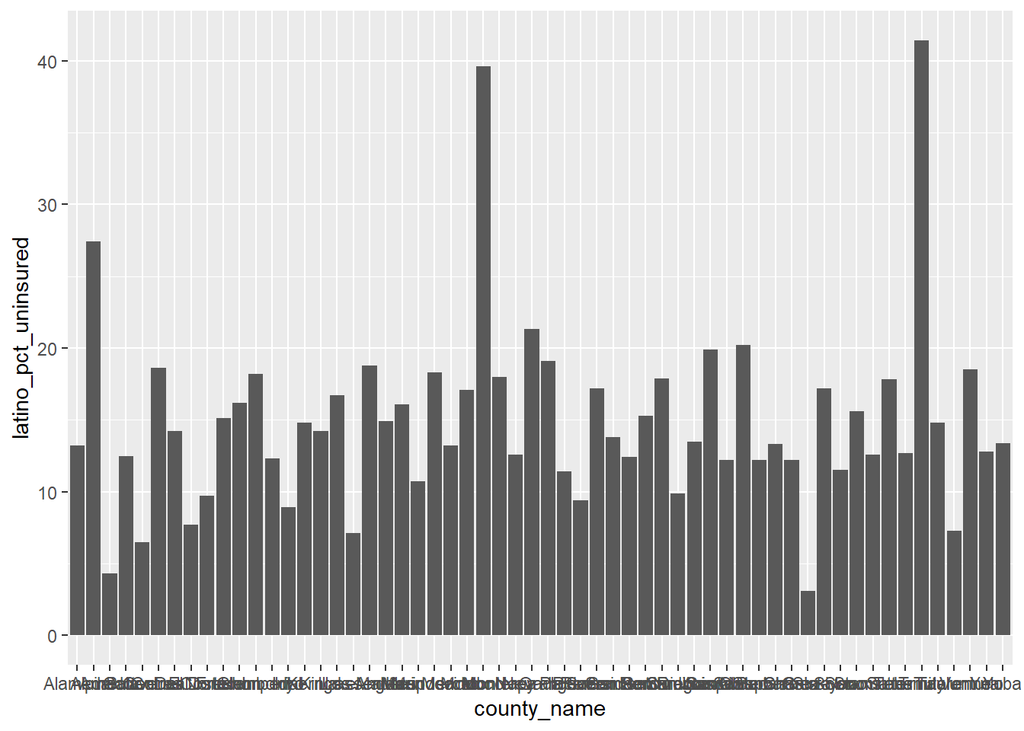

```r
## plot test
# Very basic bar graph
ggplot(data=insur, aes(x=county_name, y=latino_pct_uninsured )) +
  geom_bar(stat="identity")
```

```r
# garbage
```

### Try again

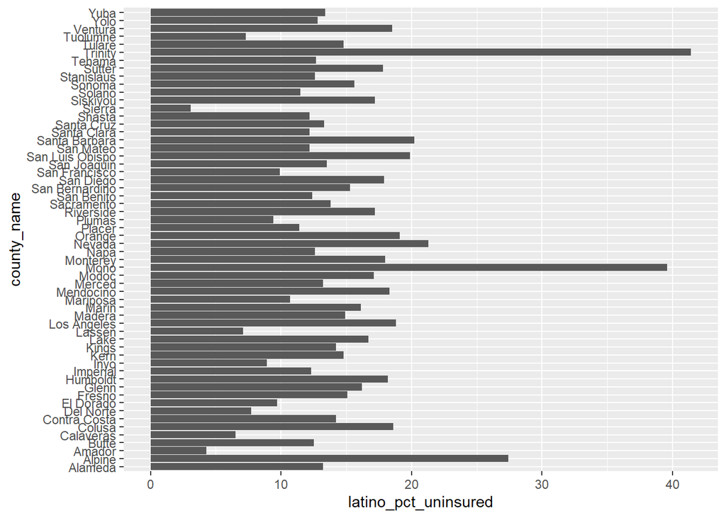

```r
ggplot(data=insur, aes(x=county_name, y=latino_pct_uninsured )) +
  geom_bar(stat="identity") +
  coord_flip()  # add a function to flip the x-y coordinates
```

```r
# better! but keep going
```

### Keep going…

Reorder counties from highest to lowest %

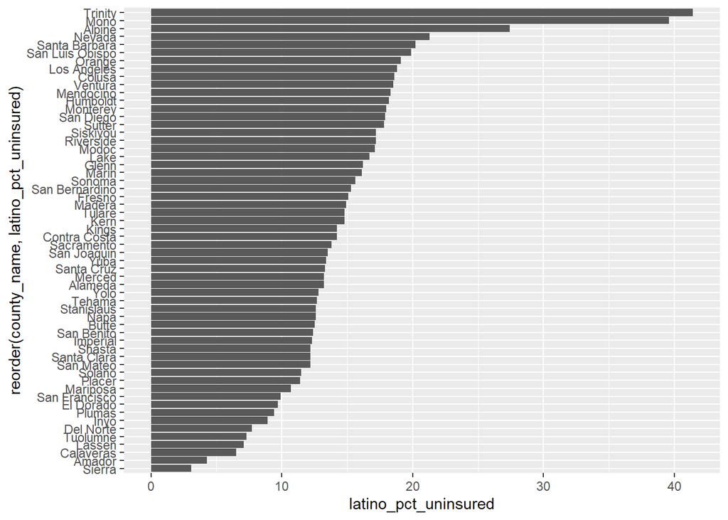

```r
# re order the counties highest to lowest
ggplot(data=insur, aes(x = reorder(county_name, latino_pct_uninsured ), y = latino_pct_uninsured )) +
  geom_bar(stat="identity") +
  coord_flip()
```

```r
# better
```

### Add color dimension

Also titles

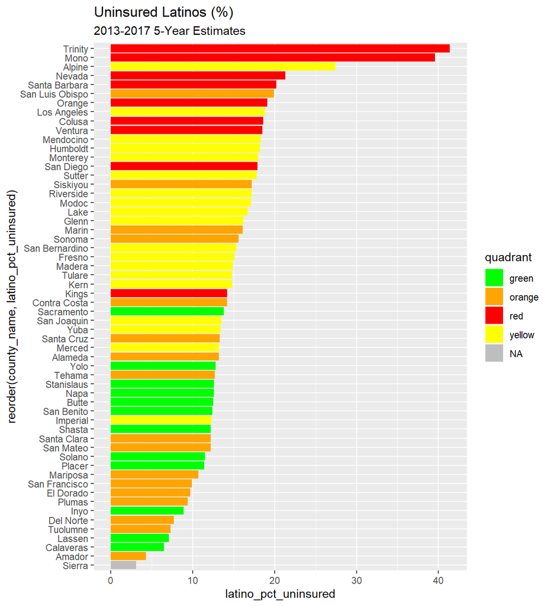

```r
# Add another dimension of the data
# color the bars by racecounts quadrant
ggplot(data=insur, aes(x = reorder(county_name, latino_pct_uninsured ),
                      y = latino_pct_uninsured , fill = quadrant)) +
  geom_bar(stat="identity") +
  scale_fill_manual(values=c("green", "orange", "red", "yellow" ), na.value="gray")+
  coord_flip()  +
  labs(title = "Uninsured Latinos (%)",
       subtitle = "2013-2017 5-Year Estimates")
```

### Add labels and experiment with themes

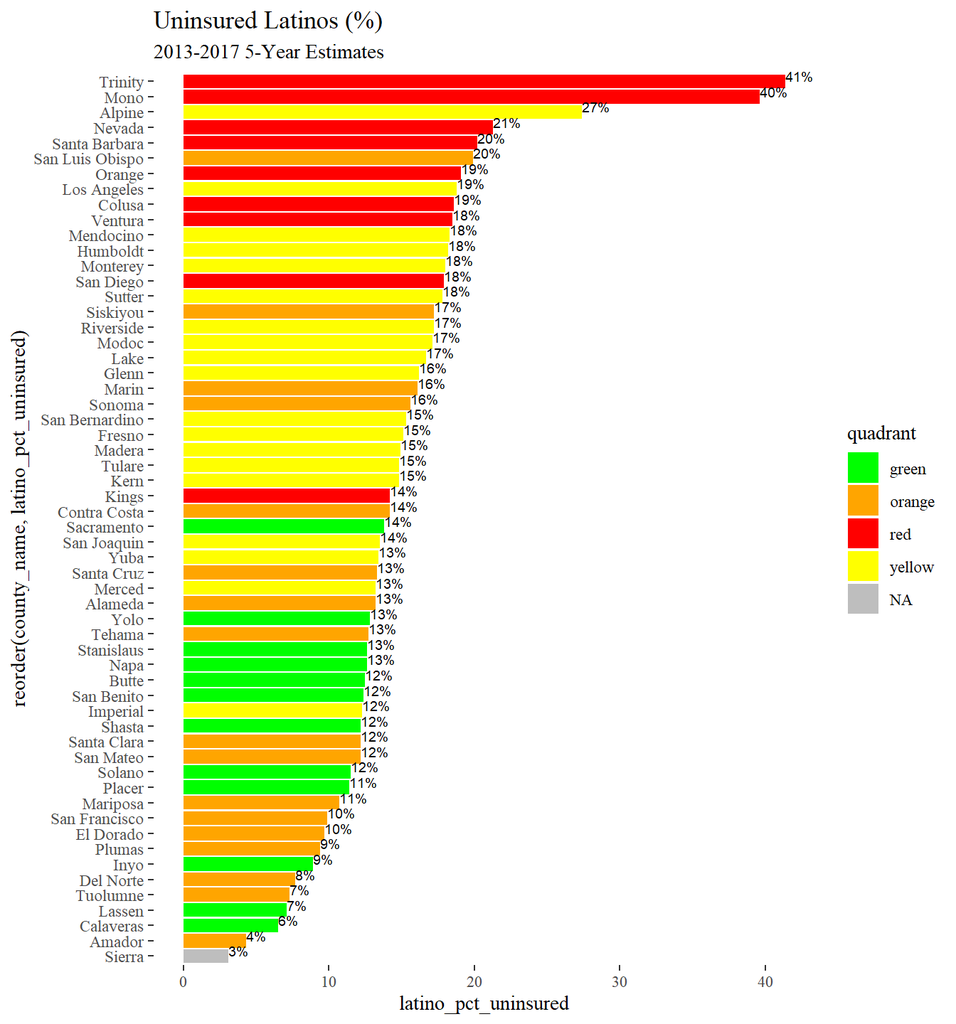

```r
# experiment with themes! add bar labels!
ggplot(data=insur, aes(x = reorder(county_name, latino_pct_uninsured ),
                      y = latino_pct_uninsured , fill = quadrant)) +
  geom_bar(stat="identity") +
  scale_fill_manual(values=c("green", "orange", "red", "yellow" ), na.value="gray")+
  coord_flip()  +
  geom_text(aes(label = paste0(round(latino_pct_uninsured, 0), "%")),  # assign the % homeowner attribute, round to 1 decimal place
            size=2.5,   # set font size
            position = position_dodge(width = 1), vjust=0 , hjust=0) + # adjust alignment of labels
  labs(title = "Uninsured Latinos (%)",
       subtitle = "2013-2017 5-Year Estimates") +
  theme_tufte()
```

```r
  # Type theme_ to get a preview of the themes available
```

# Interactive Map

### Spatial data

There are many ways to deal with spatial data in R.

The function pgGetGeom() allows us to import geometries from the Postgresql database with a WHERE clause:

```r
# load libraries
library(leaflet)
library(sf)
library(rgdal)
library(rpostgis)
library(RColorBrewer)

# Get county geometries - query county boundaries from race counts database, query only CA
shp <- pgGetGeom(con, "cb_2017_us_county_500k", clauses = "where statefp = '06'")

# review data
head(shp@data)
```

```
##   gid statefp countyfp countyns       affgeoid geoid         name lsad
## 1  19      06      001 01675839 0500000US06001 06001      Alameda   06
## 2  20      06      005 01675841 0500000US06005 06005       Amador   06
## 3  21      06      013 01675903 0500000US06013 06013 Contra Costa   06
## 4  22      06      023 01681908 0500000US06023 06023     Humboldt   06
## 5  23      06      037 00277283 0500000US06037 06037  Los Angeles   06
## 6  24      06      047 00277288 0500000US06047 06047       Merced   06
##         aland     awater
## 1  1909616630  216916717
## 2  1539933576   29470568
## 3  1857310903  225193562
## 4  9241251740 1254039383
## 5 10510588451 1794793532
## 6  5012175320  112509475
```

```r
# look at data type -- spatial df
class(shp)
```

```
## [1] "SpatialPolygonsDataFrame"
## attr(,"package")
## [1] "sp"
```

Spatial data frames are slightly different animals in R. For example, to look at the data in a spatial df above, I called `shp@data`. We don’t need to get into this too much now, just be aware.

#### Quick test plot of the shapefile

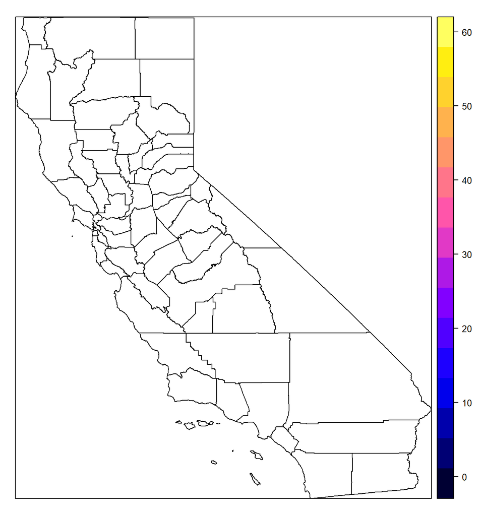

```r
# quick test plot
spplot(shp, "name")
```

```r
# yes this looks like how we were expecting
```

#### Add data to spatial df

Use the merge() function to join a data frame to a spatial data, make sure the spatial data frame is listed first in the function in order to maintain data type = spatial.

```r
# map data

# join in race counts data data
insur_dat = merge(shp, insur, by.x="name", by.y="county_name", all=TRUE)

# review data -- first 16 columns
head(insur_dat@data[,1:16])
```

```
##            name gid statefp countyfp countyns       affgeoid geoid lsad
## 1       Alameda  19      06      001 01675839 0500000US06001 06001   06
## 3        Amador  20      06      005 01675841 0500000US06005 06005   06
## 7  Contra Costa  21      06      013 01675903 0500000US06013 06013   06
## 12     Humboldt  22      06      023 01681908 0500000US06023 06023   06
## 19  Los Angeles  23      06      037 00277283 0500000US06037 06037   06
## 24       Merced  24      06      047 00277288 0500000US06047 06047   06
##          aland     awater county_id total_universe black_universe
## 1   1909616630  216916717     06001        1619367         177689
## 3   1539933576   29470568     06005          33587             31
## 7   1857310903  225193562     06013        1118246          95212
## 12  9241251740 1254039383     06023         134525           1538
## 19 10510588451 1794793532     06037       10038224         815435
## 24  5012175320  112509475     06047         264519           7839
##    aian_universe asian_universe pacisl_universe
## 1          10038         470176           13562
## 3            204            499              68
## 7           5387         179815            5514
## 12          6920           3924             418
## 19         67509        1454553           27340
## 24          1769          20163             456
```

### Static map of data

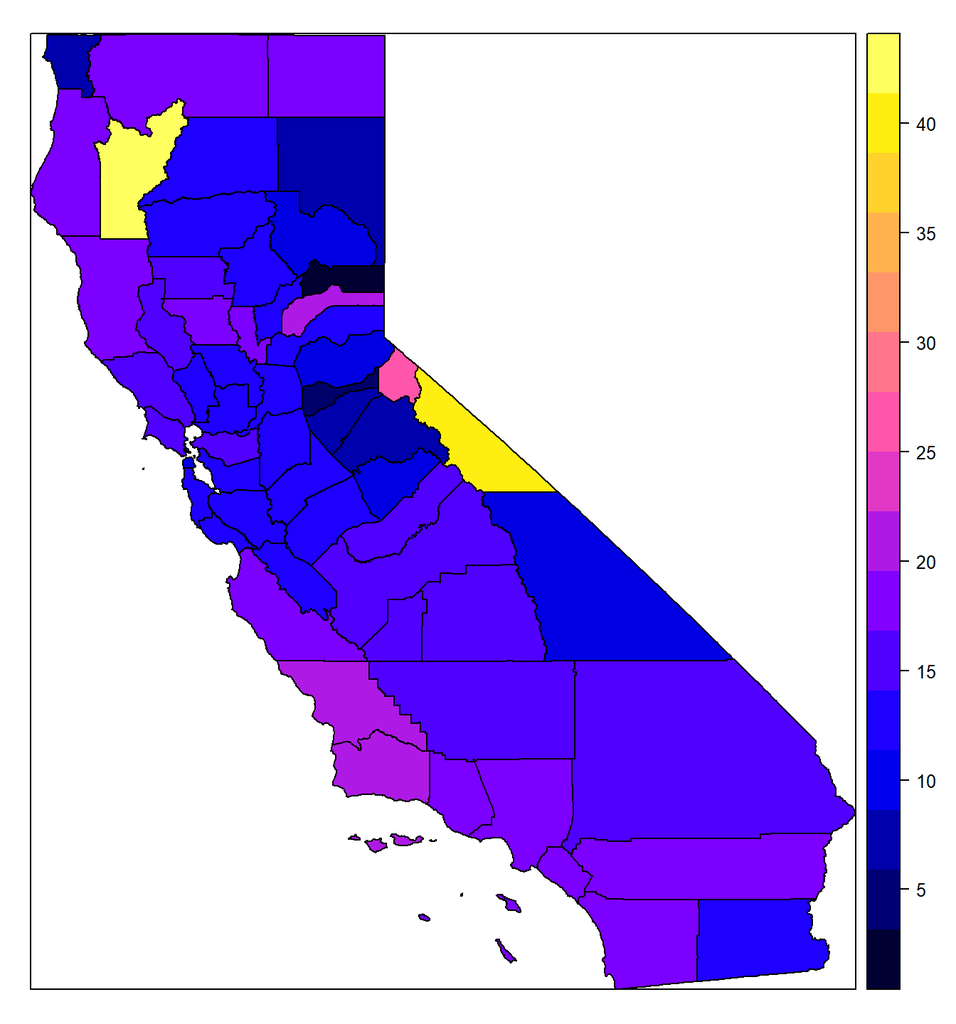

```r
# Quick test plot
spplot(insur_dat, "latino_pct_uninsured" )
```

### Interactive Map

```r
# define color palette

 pal <- colorBin(
  palette = "YlOrRd",
  domain = insur_dat$latino_pct_uninsured, bins = 5,
  pretty = FALSE
)


# map
leaflet(insur_dat) %>%                                        # call leaflet library
  addProviderTiles(providers$CartoDB.Positron) %>%   # call basemap tiles from carto

  addPolygons(data=insur_dat, color="gray",          # define data and aesthetics to be mapped
              weight=1, fillOpacity = 0.7,
              fillColor = ~pal(latino_pct_uninsured), # fill color of the polygons, using RColorBrewer palette

        # define actions & style for when the user hovers over the polygon
              highlightOptions = highlightOptions(
                                    color = "white",
                                    weight = 2,
                                    bringToFront = TRUE),

        # define popup text -- concatenate data values with text labels
            popup = paste0(insur_dat$name, " County</br>",
                       insur_dat$latino_pct_uninsured,
                       "% Uninsured Latinx")) %>%

  # add legend
  addLegend(position = "bottomleft",
            pal = pal,
            values = ~latino_pct_uninsured,
            title="Uninsured Latinos (%)" )
```

[interactive chart not shown]

# How to View and Share the Output of RMarkdown

- RMarkdown can produce htmls, Word docs or PDFs.
- HTML output is self-contained
  - Open file locally in browser (this file can be emailed to others and opened locally in their browser as well)
  - Create a Github page to host your html file

## Github

- Create a Github repository that is web page-enabled, then upload your file.
- No html/css/web programming required, R & Github take care of all of that for you. Easy peasey!

### Demo Rmarkdown to Github Workflow

- Open markdown file Example_RMarkdown.Rmd
- Knit
- Open locally
- Upload to Github Repo

…

# More Examples of R Visualizations

[Great list of chart options in R for different statistical analyses](http://r-statistics.co/Top50-Ggplot2-Visualizations-MasterList-R-Code.html)

# Nice Looking Table in R

Package called Kable

[See instructions on using Kable and examples of additional features](https://cran.r-project.org/web/packages/kableExtra/vignettes/awesome_table_in_html.html#overview)